# Make notes

1. Make notes with Prototype pNote and pSubnote

   pNote is for Sections and pSubnote is for Subsections. Please set the Prototype of pNote to level 1 and pSubnote below level.
- When creating a note, please enter “#pNote” or “#pSubnote” following the title. (or apply the pNote Prototype or pSubnote to notes you make )

  e.g. Note title -> わが輩は猫である#pSubnote
  - The note title (`$Name`) is the header for pNote or pSubnote.
- Depending on the hierarchy level, the level of the header also changes.

  e.g. If the title of pSubnote in level 2 depth is “わが輩は猫である”, it will be output as follows when exporting.

  > ## わが輩は猫である
2. Index.qmd

   In the quarto book format, **only one index.qmd is required**, `$IsIndexqmd` of the index.qmd is set to `true`. You can make the note for index.qmd with the pIndexQmd Prototype.

## Special Notes Prototype

1. pReferenceQmd

   This prototype is inherited from pNote and $Text has a div with id `refs` to call a works cited list (below). (Quarto Bibliography Generation)

   `::: {#refs}`

   `:::`
2. pAppendixQmd

   This prototype is inherited from pNote and $IsAppendix is `true`.

# Chunks and Graphs

1. R chunk and Python chunk notes

You can create a pRChunk for an R chunk and a pPChunk for a Python chunk. The “Chunk & Graph: Make Chunk List” stamp generates a tag like ＜chunk:tagname＞. These tags can be used to reference R chunks, Python chunks, Mermaid diagrams, or Graphviz code.

Please do not insert tags in the middle of a sentence.

＜chunk:tagname＞

2. Rendered Preview in Text Pane(R chunks, Mermaid diagrams, and Graphviz only) You can check the results of the code executed within an R chunk in the Preview screen. Similarly, the results of Mermaid and Graphviz code can also be displayed. However, this is not possible for Python.

# Rename HTMLExportFileName of a note with translation

There is a stamp **“Notes: Tranlate Section Labels”** that translates the Japanese title (`$Name`) into English and automatically sets `$HTMLExportFileName` [translate-shell]. and you can set `$SectionLabel` with stamp “Set: Section Label”. The labels of the section cannot be duplicated, so please modify them manually if necessary. In addition, you can change the language to be translated with `$Rename_in` in the TBX configuration note (**TBXConfig**). ( By default, from Japanese to English).

[translate-shell]: [Translate-shell](https://github.com/soimort/translate-shell) installation required.

```bash
>brew install translate-shell
```

# Part in Book format

For Part, please refer to [Quarto’s “Book Structure” reference](https://quarto.org/docs/books/book-structure.html).

pNote is compatible with quarto’s **Part** or **Chapter**.

If pNote is at the bottom of pNote, the top pNote will be Part (Part ○), and the lower pNote will be Chapter (Chapter ○). You can place pNote at hierarchical level 2 only if you are under pNote of hierarchy level 1.

In this case, the hierarchy level and header level are different, so the header level is set based on the user attribute `$OutlineDepthBase`.

pNote, which is treated as a Part, is turned on (`true`) for `$Is_Part_qmd`. The lower pNote contains the export file name (e.g. filename.qmd) of the pNote, which is Part, in `$Part_file`.

```yaml
#_quarto.yml
chapters:
  - index.qmd
  - preface.qmd
  - part: "Dice" # if $Text("Dice").wordCount == 0
  chapters:
    - basics.qmd
    - packages.qmd
```

```yaml
#_quarto.yml
chapters:
  - index.qmd
  - preface.qmd
  - part: dice.qmd # if $Text("Dice").wordCount >0
    chapters:
      - basics.qmd
      - packages.qmd
```

The figure below shows the export example when Part is supported and the output result of _quarto.yml.

[figure not shown]

Folder configuration at the time of output and _quarto.yml

# Cross-Reference using Ziplink

Convert it to a quotable title (citation name starting with @) and create a note for the corresponding part. **Tinderbox**’s **Ziplink** function [ziplink] is a function for easily pasting links to notebooks. It is diverted to make it easy to enter the quoted name. This makes it relatively easy to find and enter the quoted label even if the number increases.

[ziplink]: Please refer to “Text link creation via the Ziplinking method” in A Tinderbox Reference File.(Anderson (2024))

Anderson, Mark. 2024. “A Tinderbox Reference File.” 2024.

## How to set the label of the diagram

### Image link in markdown format

Recognize and collect labels in a format that extends the markdown.

![Test image](screenshots/toolbar.png){#fig-test fig-alt=“test” fig-align=“left” width=100%}

[figure not shown]

# airquality

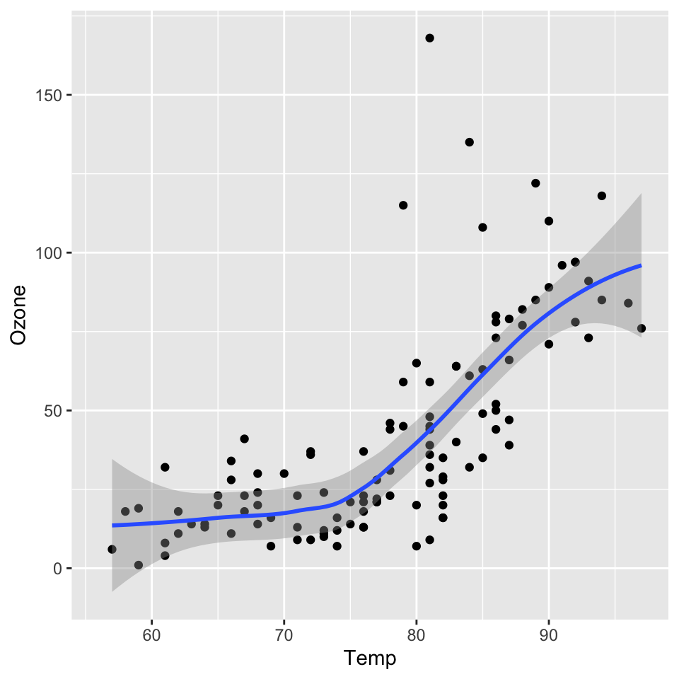

```r
library(ggplot2)
ggplot(airquality, aes(Temp, Ozone)) +
  geom_point() +
  geom_smooth(method = "loess")
```

## How to set the label of the table

There are multiple ways to specify labels, but they are only supported if it is a table in markdown format and the label name is above, as shown in the example below.[table-cross-ref]

[table-cross-ref]: For other formats, please refer to [quarto cross-reference](https://quarto.org/docs/authoring/cross-references.html#tables).

```
:明度・彩度の修飾子 {#tbl-brightness-saturation}

|項目|効果|
|----|------------|
|dark|暗くする|
|darker|より暗くする|
|darkest|最も暗くする|
|light| 明るくする|
```

明度・彩度の修飾子 {#tbl-brightness-saturation}

| 項目 | 効果 |
| --- | --- |
| dark | 暗くする |
| darker | より暗くする |
| darkest | 最も暗くする |
| light | 明るくする |

## Equations

Equation Example

$$ma^{2} \mathrm S^{2}
\frac{\partial^{2} \mathrm C}{\partial \mathrm S^2} + \mathrm r \mathrm
S \frac{\partial \mathrm C}{\partial \mathrm S}\ = \mathrm r \mathrm C$$
{#eq-black-scholes}

```latex
$$
ma^{2} \mathrm S^{2}
\frac{\partial^{2} \mathrm C}{\partial \mathrm S^2}  + \mathrm r \mathrm S \frac{\partial \mathrm C}{\partial \mathrm S}\ =  \mathrm r \mathrm C
$$
```

## How to quote

If you enter two square brackets “[[”, the list will be displayed, so please enter a part of the label name. As the candidates are narrowed down, select the citation label you want to enter.

How to quote

| Types of quotations | Lable | Quote |
| --- | --- | --- |
| Chapters, Sections etc. | #sec- | @sec- |
| Figures | #fig- #\| label:fig- %%\| label:fig- //\| label:fig- | @fig- |
| Charts | #tbl- | @tbl- |
| Equations | #eq- | @eq- |

## Dummy links for cross-reference

You can create dummy links showing where each cross-reference, starting with the @ symbol in the section, figure, and table label lists, is cited.

1. execute the “Labels: Make Dummy Link Data For Cross-Reference” stamp
2. select cross-ref label notes ( start with “@” ) and execute the “Labels: Dummy Link between Reference and Selected notes” stamp.

## Restrictions on quoted labels

- The label before change or deletion remains because it cannot be detected even if the quoted label name is changed or deleted.
- Cross-ref detection is carried out by regular expression. If it is executed in the middle of input, it will be duplicated with a short label.

In this case, if necessary, delete the quoted label name in Stamp and perform the detection manually by following the steps below.

1. Labels: Clear Cross-Reference List（Delete all citation labels under the Reference List.）
2. Labels: Make Cross-Reference List（Re-detect the quoted label.）

# Export and Render

1. Export `_quarto.yml`

2. Export `.qmd` files ( pNote notes only)

The pSubnote at the bottom of pNote at the time of output is all output as one qmd file in the state contained when pNote is exported. Therefore, it is OK to export by selecting only pNote to output. In addition, pSubnote does not require output, but if you export, it is set to output as a text file (extension .txt).

[figure not shown]

Before

[figure not shown]

After

qmd files are moved to the project path by stamp

3. Preview HTML output. ( optional )

```bash
# preview for only html output
> quarto preview index.qmd --to html --no-watch-inputs --no-browse
```

4. Render pdf or html.

```bash
> quarto render
```

```
You can use RStudio for preview and render.
```

# Example

[Example PDF](https://github.com/fryagbye/tinderboxwithquarto/blob/main/_bookpdf/Tinderbox-file-for-Quarto.pdf)